# Data Visualization

## Assignment 2

1. Replicate the following graph. The data can be found in SkullRats.sav

```r
library(haven)
SkullRats <- read_sav("Datasets/SkullRats.sav")
View(SkullRats)
```

[output not shown]

[output not shown]

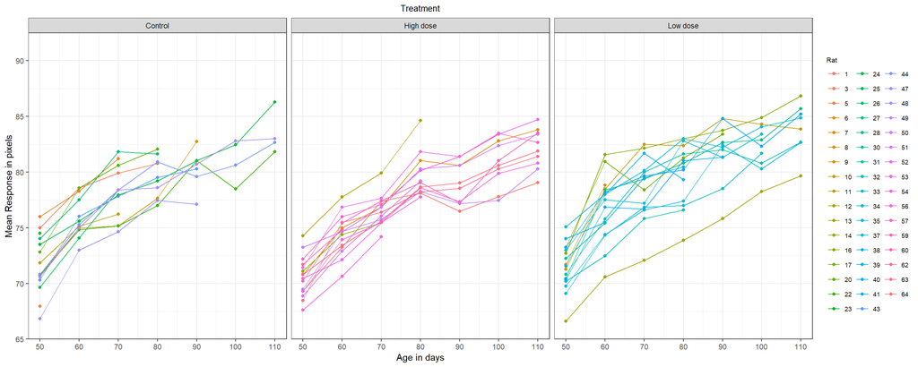

2. Create a graph indicating the mean growth of each group (average over the rats) We would be first required to find the summary data. i.e. find the mean and the confidence intervals. We have used the dplyr package to previously find the means, we will now extend it to find the standard deviation and the sample size for each timepoint/treatment combination. We then calculate the SE’s and we use the critical points of the t-distribution (we don’t naively use 1.96). The code for programming this in R is:

```r
mean_data <- group_by(SkullRats, age, treat) %>% dplyr::summarise(mean.res = mean(response,
    na.rm = TRUE), sd.res = sd(response, na.rm = TRUE), n.res = n()) %>% mutate(se.res = sd.res/sqrt(n.res),
    LCI = mean.res - qt(0.975, n.res - 1) * se.res, UCI = mean.res + qt(0.975, n.res -
        1) * se.res)

View(mean_data)
```

1. Do this by three different grids for the treatment groups

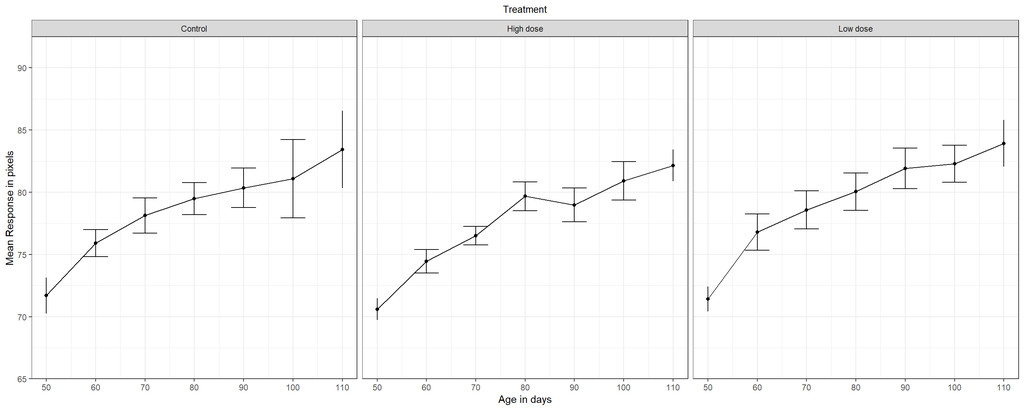

2. And on a combined plot represented by the colours red (Control), green (High dose) and blue (Low dose).

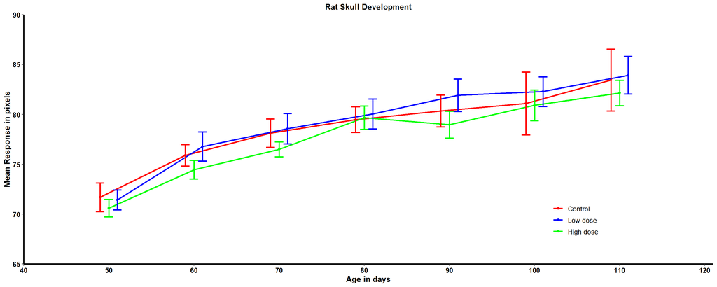